# Examples of Using the R “openair” Package for Model Evaluation

#### by Junhua Zhang

#### ARQI/AQRD/STB

#### Environment Canada

#### ARQI/AQRD/STB

#### 4905 Dufferin Street

#### Downsview, Ontario M3H 5T4

#### CANADA

#### May 1,2014

This documentation shows a few examples of how R and the “openair” package can be used for model evaluation purpose. More detailed and sophisticated uses of the “openair” package are documented in its manual http://www.openair-project.org/Downloads/OpenAirManual.aspx. The “openair” manual also provides excellent instruction on the basic concepts of R.

## 2. Loading Data into R

The input data can be loaded into R using **read.csv** command and the data can be saved into a data frame. Here the data are saved in a variable called **gmv2_2011**.

```r
## setwd('/Users/teaklesa/Documents/FromClarkRichards/GEM-MACH_Evaluation/')
gmv2_2011 <- read.csv("GMv2_2011.csv", header = TRUE)
```

Once the data are loaded into R, we can use the R **head** function to list the data:

```r
head(gmv2_2011)
```

```
##   stationid   lat    lon             date localdow o3obs o3mod no2obs
## 1     10102 47.56 -52.71 14/06/2011 22:30        2    25 21.66      6
## 2     10102 47.56 -52.71 14/06/2011 23:30        2    28 21.86      5
## 3     10102 47.56 -52.71  15/06/2011 0:30        3    31 21.75      3
## 4     10102 47.56 -52.71  15/06/2011 1:30        3    31 21.90      3
## 5     10102 47.56 -52.71  15/06/2011 2:30        3    31 22.84      2
## 6     10102 47.56 -52.71  15/06/2011 3:30        3    32 24.01      2
##   no2mod noobs nomod
## 1  2.452     2     0
## 2  1.861     2     0
## 3  1.616     1     0
## 4  1.405     2     0
## 5  1.081     2     0
## 6  0.872     1     0
```

We can also use the R **summary** function to get some basic statistics for the data: minimum, maximum, mean, median, how many missing data (NA), etc.:

```r
summary(gmv2_2011)
```

```
##    stationid             lat            lon
##  Min.   :1.01e+04   Min.   :25.6   Min.   :-149.0
##  1st Qu.:6.04e+07   1st Qu.:34.5   1st Qu.:-105.2
##  Median :2.21e+08   Median :39.4   Median : -87.7
##  Mean   :2.34e+08   Mean   :39.2   Mean   : -92.0
##  3rd Qu.:3.92e+08   3rd Qu.:43.3   3rd Qu.: -79.8
##  Max.   :8.00e+08   Max.   :63.7   Max.   : -52.7
##
##               date           localdow        o3obs           o3mod
##  11/07/2011 6:00:  1316   Min.   :0.00   Min.   : -3.0   Min.   :  0.0
##  28/06/2011 6:00:  1314   1st Qu.:1.00   1st Qu.: 20.0   1st Qu.: 30.3
##  11/07/2011 7:00:  1313   Median :3.00   Median : 32.0   Median : 43.8
##  12/07/2011 6:00:  1311   Mean   :2.92   Mean   : 33.2   Mean   : 45.7
##  28/06/2011 7:00:  1311   3rd Qu.:5.00   3rd Qu.: 45.0   3rd Qu.: 59.0
##  02/07/2011 8:00:  1307   Max.   :6.00   Max.   :160.0   Max.   :251.6
##  (Other)        :698429
##      no2obs           no2mod           noobs            nomod
##  Min.   : -3      Min.   : 0       Min.   : -3      Min.   :  0
##  1st Qu.:  2      1st Qu.: 1       1st Qu.:  0      1st Qu.:  0
##  Median :  4      Median : 2       Median :  1      Median :  0
##  Mean   :  5      Mean   : 5       Mean   :  2      Mean   :  1
##  3rd Qu.:  7      3rd Qu.: 7       3rd Qu.:  2      3rd Qu.:  1
##  Max.   :149      Max.   :74       Max.   :563      Max.   :134
##  NA's   :622721   NA's   :622721   NA's   :656770   NA's   :656770
```

## 3. Basic Statistics Calculation

The function **modStats** can be used to calculate a number of common statistics (FAC2, MB, MGE, NMB, NMGE, RMSE, r, and COE) for all stations, for individual stations, by land-use type, by wind direction, by month, by season, by weekday, by weekend, etc. See below for a few examples:

### a) O3 statistics for all stations for the whole period

```r
modStats(gmv2_2011, obs = "o3obs", mod = "o3mod")
```

```
##    default      n  FAC2    MB   MGE   NMB   NMGE  RMSE      r     COE
## 1 all data 706301 0.752 12.48 16.35 0.376 0.4927 20.76 0.6643 -0.1599
```

### b) O3 statistics for all stations by month

```r
modStats(gmv2_2011, obs = "o3obs", mod = "o3mod", type = "month")
```

```
##   month      n   FAC2    MB   MGE    NMB   NMGE  RMSE      r     COE
## 2  June 476017 0.7479 11.14 15.55 0.3438 0.4798 19.62 0.6233 -0.1508
## 1  July 230284 0.7604 15.24 18.01 0.4380 0.5177 22.93 0.7247 -0.1854
```

### c) By weekday and weekend

```r
modStats(gmv2_2011, obs = "o3obs", mod = "o3mod", type = "weekend")
```

```
##   weekend      n   FAC2    MB   MGE    NMB   NMGE  RMSE      r    COE
## 1 weekday 518211 0.7547 12.11 16.09 0.3644 0.4843 20.45 0.6666 -0.135
## 2 weekend 188090 0.7445 13.50 17.08 0.4081 0.5161 21.57 0.6592 -0.230
```

### d) For each day of the week

```r
modStats(gmv2_2011, obs = "o3obs", mod = "o3mod", type = "weekday")
```

```
##     weekday      n   FAC2     MB   MGE    NMB   NMGE  RMSE      r      COE
## 2    Monday 118062 0.7169 15.275 18.31 0.4685 0.5617 22.62 0.6657 -0.32722
## 6   Tuesday 115192 0.7266 14.448 17.91 0.4349 0.5390 22.49 0.6795 -0.22109
## 7 Wednesday  92290 0.7982  8.433 13.64 0.2541 0.4109 17.75 0.6436 -0.01803
## 5  Thursday  89369 0.7822  8.724 13.46 0.2673 0.4122 17.27 0.6774  0.03970
## 1    Friday 103298 0.7665 12.081 15.98 0.3507 0.4640 20.25 0.6917 -0.07319
## 3  Saturday  94003 0.7505 13.289 16.94 0.3946 0.5029 21.45 0.6727 -0.16250
## 4    Sunday  94087 0.7386 13.720 17.22 0.4220 0.5297 21.69 0.6446 -0.30312
```

### e) By station

For this one, we need to convert the **stationid** to **factor** type and use it to group the data by station. The statistics will be saved in a data frame named **O3statistics**.

```r
gmv2_2011$stationid <- factor(gmv2_2011$stationid)
O3statistics <- modStats(gmv2_2011, obs = "o3obs", mod = "o3mod", type = "stationid")
```

We can then check to see what the statistics look like using the **head** function:

```r
head(O3statistics)
```

```
##     stationid   n   FAC2      MB    MGE     NMB   NMGE   RMSE      r
## 24      10102 668 0.8997  6.0002  7.803 0.24305 0.3161 10.763 0.3664
## 40      10401 668 0.9626  3.5859  6.778 0.12660 0.2393  9.272 0.3225
## 43      10501 671 0.9359  3.2244  5.902 0.12404 0.2271  7.705 0.6102
## 47      10601 662 0.9517  0.4969  5.458 0.02048 0.2249  7.445 0.2994
## 242     20104 671 0.8748  9.2411 10.466 0.33951 0.3845 13.507 0.5623
## 251     20301 670 0.7851 11.8138 12.530 0.48129 0.5105 15.552 0.6427
##         COE
## 24  -0.3191
## 40  -0.4646
## 43   0.0821
## 47   0.0152
## 242 -0.6928
## 251 -0.5168
```

## 4. Examples of Various Plots

### a) Summary plot

The **summaryPlot** function can be used to plot important aspects of the data, such as time series, histogram, mean, median, minimum, and maximum of the data. It also provides information about how many data are missing. It is always good to do this plot first to have an overall view of the data. e.g.,

```
##     date1     date2     o3obs     o3mod    no2obs    no2mod     noobs
## "POSIXct"  "POSIXt" "numeric" "numeric" "numeric" "numeric" "numeric"
##     nomod
## "numeric"
```

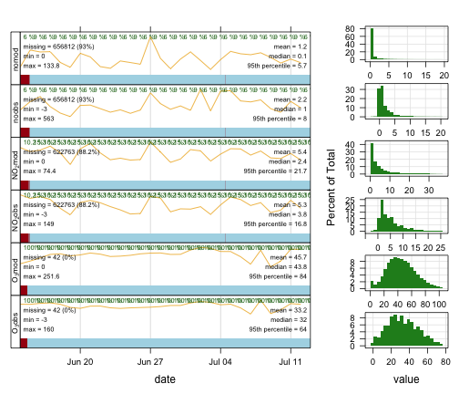

```r
summaryPlot(subset(gmv2_2011, select = c(date, o3obs, o3mod, no2obs, no2mod,
    noobs, nomod)), period = "day")
```

**Note:** **subset** is used here to select a subset of the data (date, o3obs, o3mod, no2obs, no2mod, noobs, and nomod) for the plot. Otherwise, all of the fields, including Latitude and Longitude, will be plotted. **subset** is a very useful function to select a subset of the data. For example, we can use it to select the data in a subregion on which to calculate statistics.

### b) Time variation plots

This is another useful summary plot. With one function (**timeVariation**), it plots several time variations: hourly variation on each day of the week, average hourly variation, monthly variation, and daily variation on each day of the week, e.g., time variation of observed and modeled O3:

#### Observed Time Variation

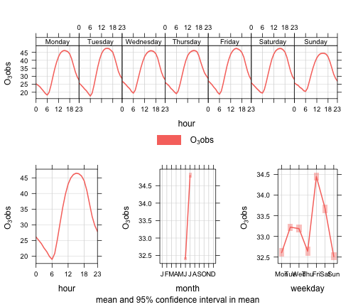

```r
timeVariation(gmv2_2011, pollutant = "o3obs")
```

#### Modeled Time Variation

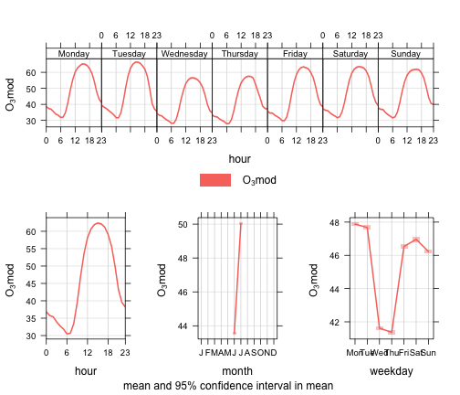

```r
timeVariation(gmv2_2011, pollutant = "o3mod")
```

### c) Split time variation plots for two period

The **splitByDate** function can be used to split the data into two periods and then plot the time variation for the two periods. The example below shows the time variation of observed O3 split at June 28 (Note: because this dataset is only for a short time period: June 15-July 12, the monthly and weekday variation are not representative, but it gives the idea of how this analysis works).

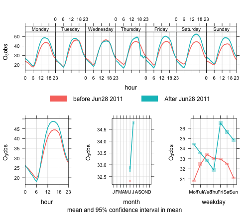

```r
gmv2_2011_new <- splitByDate(gmv2_2011, dates = "28/6/2011", labels = c("before Jun28 2011",
    "After Jun28 2011"))
timeVariation(gmv2_2011_new, pollutant = "o3obs", group = "split.by")
```

### 4) Correlation matrix plot

The **corPlot** can be used to plot correlation among several variables, e.g.

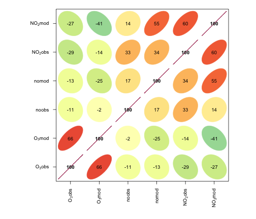

```r
corPlot(gmv2_2011, pollutant = c("o3obs", "o3mod", "no2obs", "no2mod", "noobs",
    "nomod"))
```

### 5) Scatter plots

The **scatterplot** function can be used to make many useful plots. Here are few examples:

#### a) Density scatter plot

The points of the scatter plot are color coded by the number of points. It is useful to show where the majority of the points are, especially useful for large data sets.

```r
scatterPlot(gmv2_2011, x = "o3obs", y = "o3mod", method = "hexbin", col = "jet")
```

[output not shown]

[output not shown]

#### b) Density scatter plot by month and by weekday/weekend

```r
scatterPlot(gmv2_2011, x = "o3obs", y = "o3mod", method = "hexbin", col = "jet",
    type = c("month", "weekend"))
```

[output not shown]

[output not shown]

#### c) Scatter plot colour-coded by a third variable

The following scatter plot of O3obs vs O3mod is colour-coded by the modelled NO2 concentration.

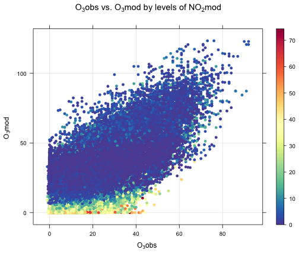

```r
scatterPlot(gmv2_2011, , x = "o3obs", y = "o3mod", z = "no2mod")
```

#### d) Scatter plot colour-coded by third variable, by season, by weekday/weekend

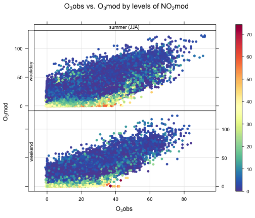

```r
scatterPlot(gmv2_2011, , x = "o3obs", y = "o3mod", z = "no2mod", type = c("season",
    "weekend"))
```

#### e) Scatter plot colour-coded by third variable, by month, by weekday

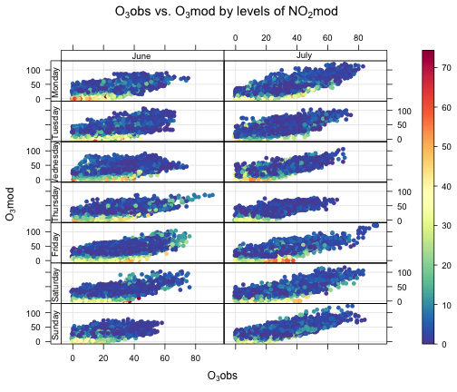

```r
scatterPlot(gmv2_2011, , x = "o3obs", y = "o3mod", z = "no2mod", type = c("month",
    "weekday"))
```

### 6) Plotting a Field on a Map

The **GoogleMapsPlot** function can be used to plot a field on a map. As an example, several O3statistics will be plotted on a map below. To do this, the latitude and longitude of the stations are extracted from the original dataset and then merged with the O3statistics by the following two setups:

#### s1) extract the lat, lon of each station using **subset** function and remove duplication using “!duplicated(stationid)”:

```r
stationLocation <- subset(subset(gmv2_2011, select = c("stationid", "lat", "lon")),
    !duplicated(stationid))
```

#### s2) merge O3statistics with lat, lon for each station using the **merge** function

```r
O3statistics <- merge(O3statistics, stationLocation)
```

Below are a few examples of plotting station statistics on a map:

#### a) Plotting O3 correlation coefficients on a map for the whole domain

[figure not shown]

```r
require(RgoogleMaps)
GoogleMapsPlot(O3statistics, lat = "lat", long = "lon", pollutant = "r", maptype = "roadmap",
    col = "jet", cex = 1, size = c(640, 440))
```

[figure not shown]

```r
GoogleMapsPlot(subset(O3statistics, lat >= 40 & lon >= -90), lat = "lat", long = "lon",
    pollutant = "r", maptype = "roadmap", col = "jet", cex = 1, size = c(440,
        240))
```

#### c) Plotting RMSE over the Greater Toronto Area

[figure not shown]

```r
GoogleMapsPlot(subset(O3statistics, lat < 44 & lat > 43.5 & lon < -79 & lon >
    -80), lat = "lat", long = "lon", pollutant = "RMSE", maptype = "roadmap",
    col = "jet", cex = 3, size = c(500, 500))
```

#### d) Plotting RMSE over the GTA, but change the base map to a satellite image

[figure not shown]

```r
GoogleMapsPlot(subset(O3statistics, lat < 44 & lat > 43.5 & lon < -79 & lon >
    -80), lat = "lat", long = "lon", pollutant = "RMSE", maptype = "satellite",
    col = "jet", cex = 3, size = c(500, 500))
```

### 7) Taylor Diagram

The **TaylorDiagram** function can be used to plot a Taylor diagram as shown below, as an example, for the comparison of O3 between model and observations.

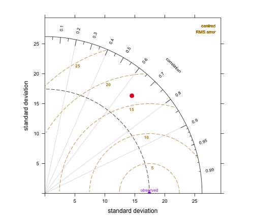

```r
TaylorDiagram(gmv2_2011, obs = "o3obs", mod = "o3mod")
```

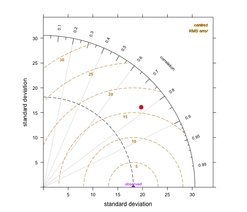

```r
TaylorDiagram(subset(gmv2_2011, lat < 34 & lat > 33 & lon < -111 & lon > -112),
    obs = "o3obs", mod = "o3mod")
```